# Machine Learning Exercise

Gek Paard

Friday, March 13, 2015

## Introduction

In the MOOC course “Practical Machine Learning” of the Johns Hopkins University the project is to investigate the Weight Lifting Exercises Dataset which is generously provided by the investigators. See their paper: Velloso, E.; Bulling, A.; Gellersen, H.; Ugulino, W.; Fuks, H. Qualitative Activity Recognition of Weight Lifting Exercises. Proceedings of 4th International Conference in Cooperation with SIGCHI (Augmented Human ’13) Stuttgart, Germany: ACM SIGCHI, 2013. See also http://groupware.les.inf.puc-rio.br/har.  
The dataset consists of measurements by sensors on six individuals who performed the Unilateral Dumbbell Biceps Curl. The measurements were made by sensors on the forearm, biceps, belt and dumbbell. The curl had to be performed in five different ways. This manner is found in the variable “classe” in the training set. Class “A” is the good one, and the classes “B”, “C”, “D” and “E” are wrong performances. The subjects were superviced by trained personell who made sure that the exercises where performed in the correct right or wrong manner. The purpose of this exercise is to predict from the measurements the manner in which they did the exercises.

## Investigation

First of all I loaded the required packages needed for this investigation.

```r
library(caret)
library(randomForest)
```

```r
trainset  <- read.csv("pml-training.csv")
inTrain   <- createDataPartition(trainset$classe, p = 3/4)[[1]]
traindata <- trainset[ inTrain,]
valdata   <- trainset[-inTrain,]
testset   <- read.csv ("pml-testing.csv")
dim(trainset)
```

```
## [1] 19622   160
```

As can be seen there a lot of variables. Many of them wil not be relevant predictors. The first 7 variables can not be relevant, because they are about who performed the exercise, on which time, the following number etc. So I removed them from the training set. Then I set the abundance of NA’s to zero’s, because randomForest can’t cope with NA’s. (I choose randomForest because the train function of caret takes a very long time.) Then I removed all the variables with little or no variation from the dataset. They can’t not be important predictors.

```r
traindata   <- trainset
traindata   <- traindata[,-(1:7)]
traindata[is.na(traindata)] <- 0
nzv         <- nearZeroVar(traindata)
traindata   <- traindata[-nzv]
```

Then I checked for correlations in the remaining variables. There are several.

```r
M <- abs(cor(traindata[,-53]))
diag(M) <- 0
correlations <- which(M> 0.8, arr.ind=T)
correlations
```

```
##                  row col
## yaw_belt           3   1
## total_accel_belt   4   1
## accel_belt_y       9   1
## accel_belt_z      10   1
## accel_belt_x       8   2
## magnet_belt_x     11   2
## roll_belt          1   3
## roll_belt          1   4
## accel_belt_y       9   4
## accel_belt_z      10   4
## pitch_belt         2   8
## magnet_belt_x     11   8
## roll_belt          1   9
## total_accel_belt   4   9
## accel_belt_z      10   9
## roll_belt          1  10
## total_accel_belt   4  10
## accel_belt_y       9  10
## pitch_belt         2  11
## accel_belt_x       8  11
## gyros_arm_y       19  18
## gyros_arm_x       18  19
## magnet_arm_x      24  21
## accel_arm_x       21  24
## magnet_arm_z      26  25
## magnet_arm_y      25  26
## accel_dumbbell_x  34  28
## accel_dumbbell_z  36  29
## gyros_dumbbell_z  33  31
## gyros_forearm_z   46  31
## gyros_dumbbell_x  31  33
## gyros_forearm_z   46  33
## pitch_dumbbell    28  34
## yaw_dumbbell      29  36
## gyros_forearm_z   46  45
## gyros_dumbbell_x  31  46
## gyros_dumbbell_z  33  46
## gyros_forearm_y   45  46
```

If a variable correlates with only one other variable I choose to remove the one with the least variation. See the plots below. If variables correlate with more than one other variables I choose to keep the one which has the most correlations. For instance the variable roll-belt correlates with yaw-belt, total-accel-belt, accel-belt-y and accel-belt-z. But yaw-belt only correlates to roll-belt. roll-belt, total-accel-belt, accel-belt-y and accel-belt-ze correlates to each other.

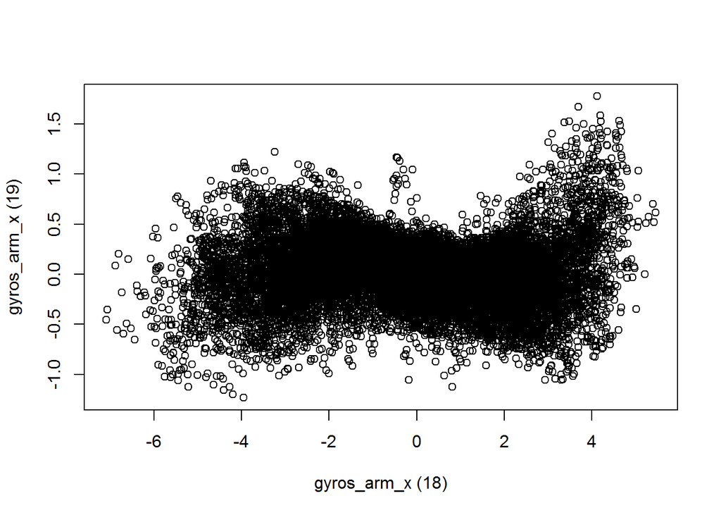

```r
smallTrain <- traindata[,c(18,19)]
prComp <- prcomp(smallTrain)
plot(prComp$x[,1], prComp$x[,2], xlab= "gyros_arm_x (18)", ylab = "gyros_arm_x (19)")
```

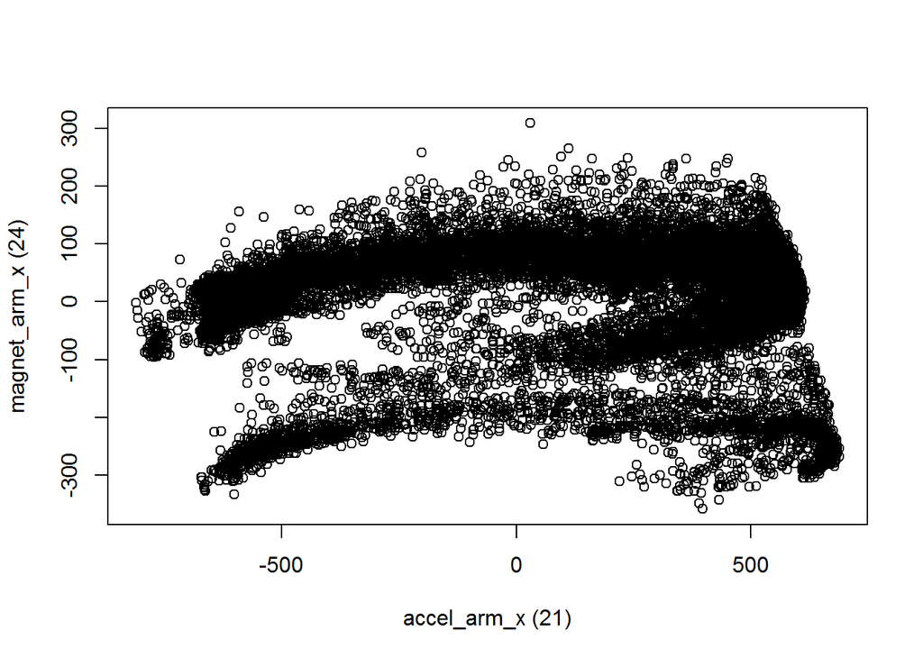

```r
smallTrain <- traindata[,c(21,24)]
prComp <- prcomp(smallTrain)
plot(prComp$x[,1], prComp$x[,2], xlab= "accel_arm_x (21)", ylab = "magnet_arm_x (24)")
```

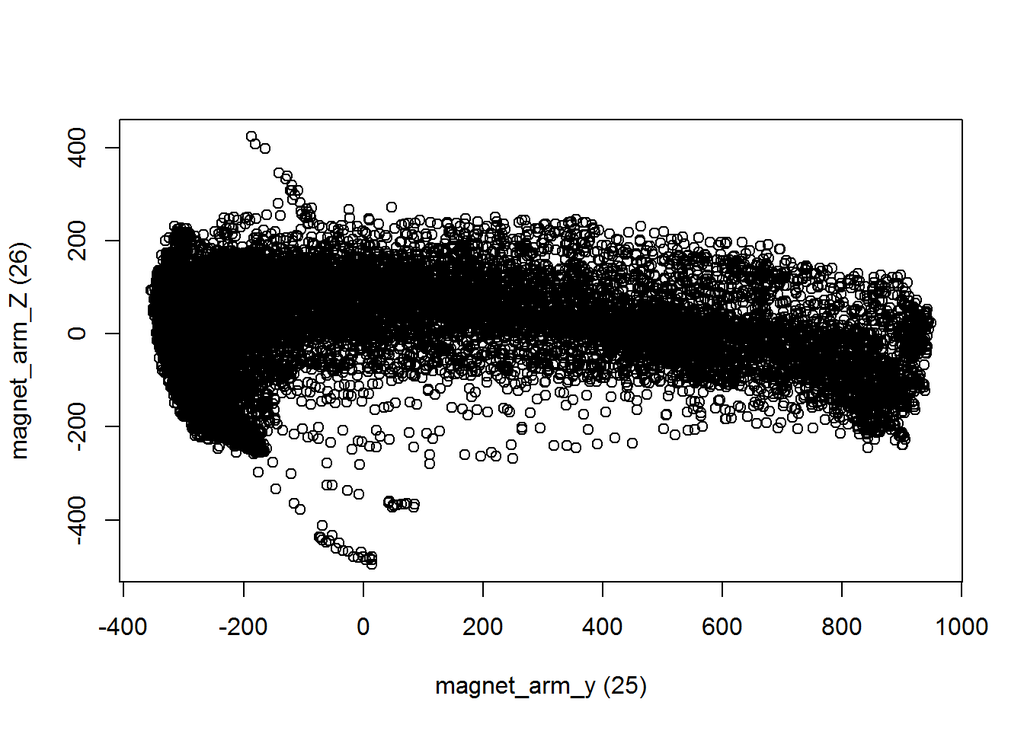

```r
smallTrain <- traindata[,c(25,26)]
prComp <- prcomp(smallTrain)
plot(prComp$x[,1], prComp$x[,2], xlab= "magnet_arm_y (25)", ylab = "magnet_arm_Z (26)")
```

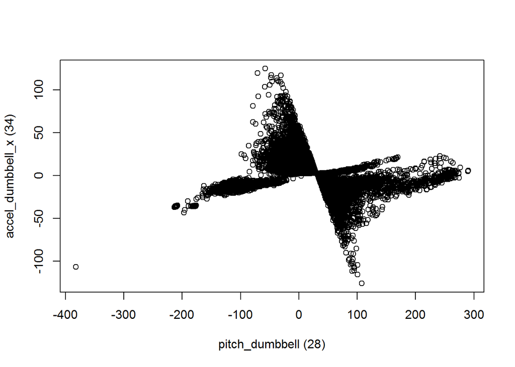

```r
smallTrain <- traindata[,c(28,34)]
prComp <- prcomp(smallTrain)
plot(prComp$x[,1], prComp$x[,2], xlab= "pitch_dumbbell (28)", ylab = "accel_dumbbell_x (34)")
```

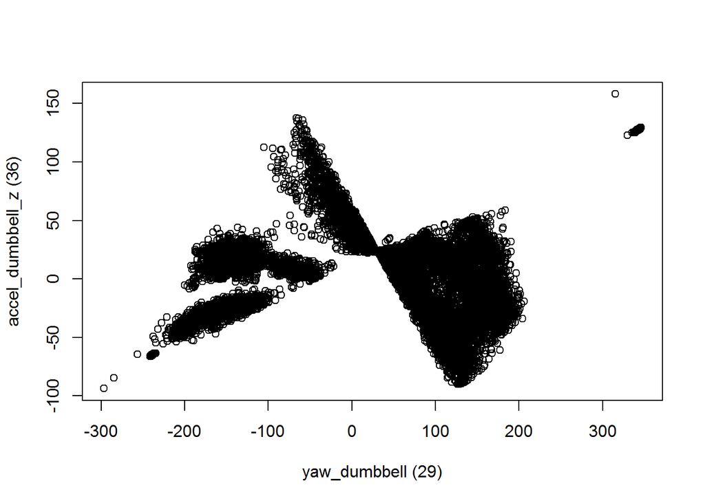

```r
smallTrain <- traindata[,c(29,36)]
prComp <- prcomp(smallTrain)
plot(prComp$x[,1], prComp$x[,2], xlab= "yaw_dumbbell (29)", ylab = "accel_dumbbell_z (36)")
```

```r
traindata <- traindata[,-45]
traindata <- traindata[,-36]
traindata <- traindata[,-34]
traindata <- traindata[,-33]
traindata <- traindata[,-31]
traindata <- traindata[,-26]
traindata <- traindata[,-24]
traindata <- traindata[,-19]
traindata <- traindata[,-11]
traindata <- traindata[,-10]
traindata <- traindata[,-9]
traindata <- traindata[,-8]
traindata <- traindata[,-4]
traindata <- traindata[,-3]
dim(traindata)
```

```
## [1] 19622    39
```

```r
set.seed(3436)
modFit1rF <- randomForest(classe ~ ., data=traindata)
predictionClassedata  <- predict(modFit1rF, valdata)
confusionMatrix(predictionClassedata, valdata$classe)
```

```
## Confusion Matrix and Statistics
##
##           Reference
## Prediction    A    B    C    D    E
##          A 1395    0    0    0    0
##          B    0  949    0    0    0
##          C    0    0  855    0    0
##          D    0    0    0  804    0
##          E    0    0    0    0  901
##
## Overall Statistics
##
##                Accuracy : 1
##                  95% CI : (0.999, 1)
##     No Information Rate : 0.284
##     P-Value [Acc > NIR] : <2e-16
##
##                   Kappa : 1
##  Mcnemar's Test P-Value : NA
##
## Statistics by Class:
##
##                      Class: A Class: B Class: C Class: D Class: E
## Sensitivity             1.000    1.000    1.000    1.000    1.000
## Specificity             1.000    1.000    1.000    1.000    1.000
## Pos Pred Value          1.000    1.000    1.000    1.000    1.000
## Neg Pred Value          1.000    1.000    1.000    1.000    1.000
## Prevalence              0.284    0.194    0.174    0.164    0.184
## Detection Rate          0.284    0.194    0.174    0.164    0.184
## Detection Prevalence    0.284    0.194    0.174    0.164    0.184
## Balanced Accuracy       1.000    1.000    1.000    1.000    1.000
```